# Time Series

David Domínguez** **Arturo Silva** **Luis González** **Alberto Valiente** **André Ramírez** **Bruno Díaz

February 24, 2025

[figure not shown]

Foto FOREIGN AFFAIRS LATINOAMÉRICA

## Librerias

```r
# Manipulación y Transformación de Datos
library(dplyr)      # Manipulación y transformación de datos (filter, mutate, group_by, summarise)
library(tidyr)      # Organización y estructuración de datos en formato "tidy" (spread, gather, pivot_longer, pivot_wider)
library(purrr)      # Programación funcional y manejo de listas
library(janitor)    # Limpieza y formateo de datos (clean_names, remove_empty)

# Importación y Lectura de Archivos
library(readr)      # Lectura rápida de archivos de texto (CSV, TSV, etc.)
library(readxl)     # Importación de archivos Excel

# Visualización de Datos y Gráficos
library(ggplot2)    # Creación de gráficos avanzados y personalizables
library(reshape2)   # Transformación de datos en diferentes estructuras para visualización
library(corrplot)   # Visualización de matrices de correlación
library(rpart.plot) # Visualización de árboles de decisión

# Modelado y Análisis Estadístico
library(rpart)      # Modelos de árboles de decisión para clasificación y regresión
library(plm)        # Manejo de datos en formato de panel para modelos econométricos

# Manipulación de Cadenas de Texto
library(stringr)    # Manipulación de cadenas de texto (regex, detección de patrones, etc.)
library(stringi)    # Procesamiento avanzado de cadenas (Unicode, conteo de caracteres, etc.)

# Manejo de Fechas y Tiempos
library(lubridate)  # Manipulación de fechas y tiempos en R

# Generación de Informes y Tablas en R Markdown
library(knitr)      # Creación de documentos dinámicos en R Markdown
library(kableExtra) # Mejora del formato y estilo de las tablas generadas con knitr::kable

# Geoespacial y Mapas
library(sf)                # Análisis y manipulación de datos espaciales en formato "Simple Features"
#library(rnaturalearth)     # Obtención de mapas geoespaciales de todo el mundo
#library(rnaturalearthdata) # Conjunto de datos espaciales adicionales para mapas

# Animaciones y Visualización Dinámica
library(gganimate)  # Creación de animaciones en gráficos de R
library(transformr) # Transiciones suaves en animaciones con gganimate

# Tests de Diagnóstico
library(lmtest)     # Pruebas de diagnóstico para modelos estadísticos
library(car)        # Funciones auxiliares para análisis estadístico y econométrico

# Series de Tiempo y Análisis Avanzado
library(xts)       # Manejo y análisis de series de tiempo (extensible)
library(zoo)       # Infraestructura para series de tiempo irregulares
library(tseries)   # Pruebas de hipótesis y análisis de series de tiempo
library(stats)     # Funciones estadísticas básicas (incluye modelos ARIMA, etc.)
library(forecast)  # Modelado y predicción de series de tiempo con modelos ARIMA y más
library(astsa)     # Herramientas para análisis de series de tiempo (especialmente para ARIMA)
library(AER)       # Recursos para econometría aplicada
library(vars)      # Modelos VAR (vectores autoregresivos)
library(dynlm)     # Modelos lineales dinámicos para series de tiempo
library(mFilter)   # Filtros económicos para series de tiempo (como Hodrick-Prescott)
library(TSstudio)  # Herramientas interactivas para explorar y analizar series de tiempo
library(dygraphs)  # Visualización interactiva de series de tiempo
library(quantmod)  # Modelado cuantitativo financiero y series de tiempo
```

## Dataset

#### Glosario:

- **new_fdi:** New Foreign Direct Investment Inflows. Millions of Dollars.
- **exchange_rate:** MXN pesos per 1 USD
- **inpc:** National Price Consumer Index. 2018 = 100
- **exports_dollars:** Value of exports. Thousands of dollars.

## Introducción

#### 1. Describir las principales características de una base de datos de series de tiempo.

- **Optimización para datos temporales:** Cada registro contiene una marca de tiempo que funciona como índice principal, lo que facilita su recuperación y el análisis de datos en relación al tiempo.
- **Manejo de series temporales irregulares y regulares:** Es posible gestionar datos con intervalos de tiempo constantes o variables adaptándose a las distintas necesidades de aplicación.
- **Integración con herramientas de monitoreo y anáisis en tiempo real:** Se integran fácilmente con sistemas que requieran análisis en tiempo real, como aplicaciones financieras, dispositivos IoT y monitoreo de infraestructura.

#### 2. Brevemente describir cómo el análisis de datos de series de tiempo puede contribuir a pronosticar cambios y/o patrones en los flujos de inversión extranjera directa (IED) asociadas con descisiones de “Nearshoring” para el caso de México.

El enfoque de los cambios y patrones en los flujos de Inversión Extranjera Directa permiten identificar tendencias y ciclos en la misma a lo largo del tiempo, facilitando la comprensión de cómo factores económicos y políticos tienen influencia en la relocalización de cadenas productivas hacia México. Datos recientes muestran aumentos significativos en la IED hacia industrias beneficiadas por el nearshoring, destacando estados como Nuevo León y Aguascalientes. Sin embargo, la IED no siempre refleja por completo el fenómeno, ya que algunas empresas financian sus expansiones con recursos locales o modelos alternativos. Para verlo de forma más amplia, es recomendable combinar el análisis de series de tiempo con métricas distintas como puede ser la actividad exportadora.

## Visualización de Datos

Preprocesamiento para formatear los cuartos para ser compatibles con TS

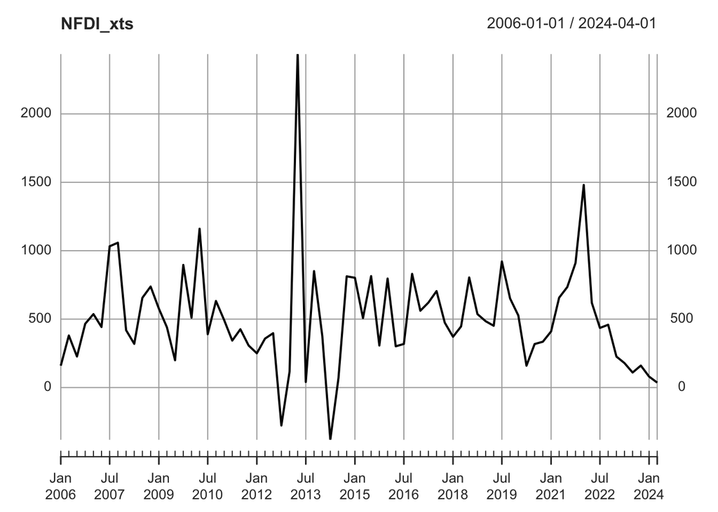

```r
nearshoring_ts$real_Mxn_New_FDI_Inflows = ((nearshoring_ts$New_FDI_Inflows * nearshoring_ts$Exchange_Rate) / nearshoring_ts$INPC)

nearshoring_ts$Quarter_formatted <- factor(nearshoring_ts$Quarter,
                                 levels = c("I", "II", "III", "IV"),
                                 labels = c("Q1", "Q2", "Q3", "Q4"))

nearshoring_ts$yearqtr_str <- paste(nearshoring_ts$Year, nearshoring_ts$Quarter_formatted)

# Convertir la cadena a un objeto yearqtr
nearshoring_ts$yearqtr <- as.yearqtr(nearshoring_ts$yearqtr_str, format = "%Y Q%q")
# Convertir el objeto yearqtr a una fecha.
nearshoring_ts$date <- as.Date(nearshoring_ts$yearqtr, frac = 0)
# Ordenar el data frame por la fecha recién creada
nearshoring_ts <- nearshoring_ts[order(nearshoring_ts$date), ]
# Paso 6: Crear el objeto xts usando la columna de fechas como índice
NFDI_xts <- xts(nearshoring_ts$real_Mxn_New_FDI_Inflows, order.by = nearshoring_ts$date)

plot(NFDI_xts)
```

```r
# Convertir variables con negativos a log
nearshoring_ts$log_real_mxn_new_fdi <- ifelse(
  nearshoring_ts$real_Mxn_New_FDI_Inflows >= 0,
  log(nearshoring_ts$real_Mxn_New_FDI_Inflows + 1),
  -log(abs(nearshoring_ts$real_Mxn_New_FDI_Inflows))
)

ts_log <- as.ts(nearshoring_ts$log_real_mxn_new_fdi)
```

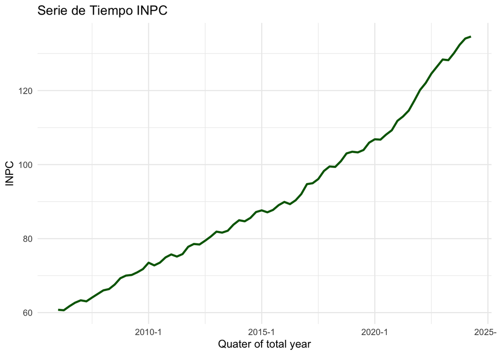

INPC explicado mediante la división anual en cuartos, nos arroja una serie de tiempo con una tendencia claramente positiva y alcista, tomando en cuenta que no es en sutotalidad lineal, incluye momentos de desacelere en el crecimiento através del tiempo. Debido a esto, no es una serie estacionaria, ya que el indice promedio no muestra constancia, con un claro crecimiento. Aunque la gráfica no muestra una estacionalidad muy marcada, es importante realizar pruebas complementarias apra descartar esto.

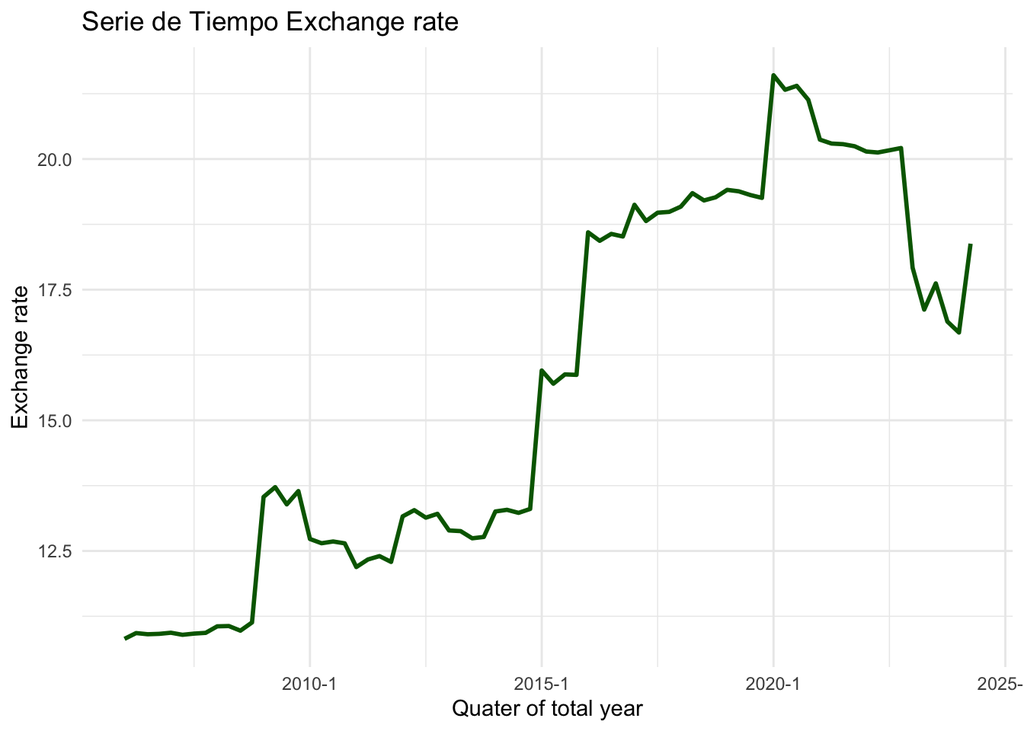

La serie muestra una tendencia ascendente con cariabilidad, tomandom una variable lineal en cuanto a su crecimiento, observamos ciertas fluctuaciones o desaceleres en su crecimiento, haciendo mucho más volátil este crecimiento. Se observan períodos de estabilidad, con un crecimiento en menor velocidad hasta el año 2015, lo que sugiere una estabilidad monetaria. Después toma un comportamiento creciente, lo que sugiere el deterioro de la moneda contra la moneda extranejera. Puede no tener presencia de estacionalidad gracias a la tendencia, pero es necesario verificar estacionariedad, ya que puede tener componentes cíclicos dentro del comportamiento de la misma.

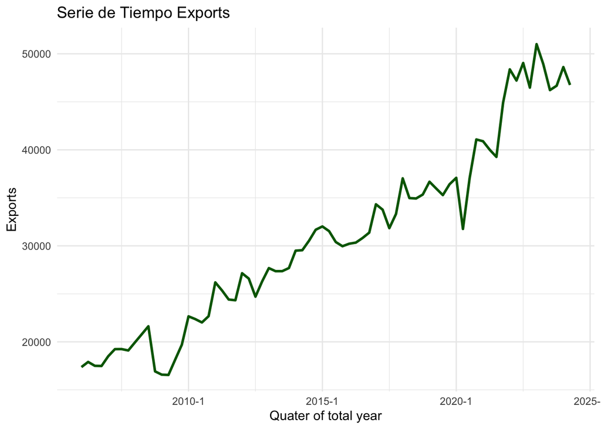

Observamos una tendencia ascendente, misma que sugiere el aumento en el valor de las exportaciones, al mismo tiempo sugiere una expansión en el crecimiento del sector en México. Observamos un crecimiento acelerado, con fluctuaciones claves y picos detectables, después del año 2022, observamos una volátilidad mayor, lo que genera más incertidumbre en el comercio internacional e inversiones dentro del país. Esta volatilidad sugiere la posible presencia de no estacionariedad y heterocedasticidad, características que requieren análisis estadísticos específicos.”

## Pruebas de Diagnostico Iniciales

```r
adf.test(nearshoring_ts$real_Mxn_New_FDI_Inflows)
```

```
##
##  Augmented Dickey-Fuller Test
##
## data:  nearshoring_ts$real_Mxn_New_FDI_Inflows
## Dickey-Fuller = -4.5379, Lag order = 4, p-value = 0.01
## alternative hypothesis: stationary
```

La prueba Dickey-Fuller (ADF) arrojó un valor p de 0.01, al ser inferior a 0.05, se rechaza la hipótesis nula de no estacionariedad, concluyendo que la serie en cuestión es estacionaria.

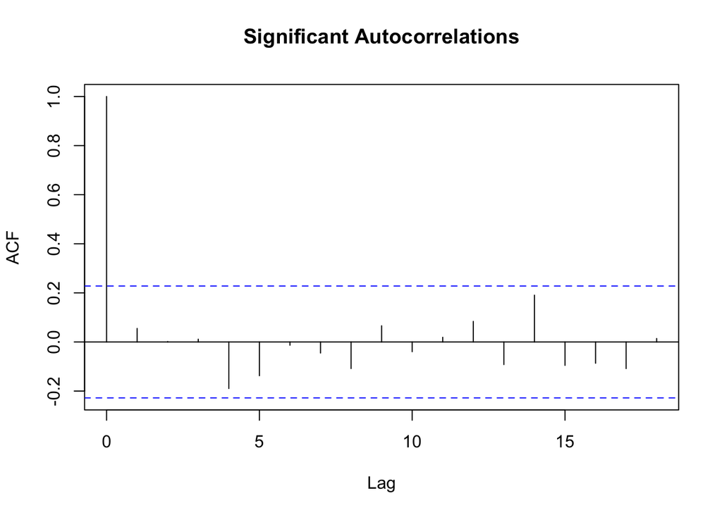

```r
acf(nearshoring_ts$real_Mxn_New_FDI_Inflows,main="Significant Autocorrelations")
```

La función de autocorrelación (ACF) no evidenció autocorrelación serial significativa, ya que desde el lag 1 todos los coeficientes se mantuvieron por debajo de los rangos de confianza. El lag 4 presentó el mayor nivel de ACF, pero sin alcanzar la significancia estadística.

> **Nota:**  
> Dado que la serie es estacionaria, no es necesario aplicar transformaciones iniciales ni ajustar un modelo ARIMA para inducir estacionariedad. En este caso, se puede proceder directamente al análisis o al modelado ARMA y VAR.

## Estimación de Modelos de Series de Tiempo

### ARMA

```r
summary(ARMA.fdi<-arma(nearshoring_ts$real_Mxn_New_FDI_Inflows, order=c(1,1)))
```

```
##
## Call:
## arma(x = nearshoring_ts$real_Mxn_New_FDI_Inflows, order = c(1,     1))
##
## Model:
## ARMA(1,1)
##
## Residuals:
##     Min      1Q  Median      3Q     Max
## -896.15 -200.08  -58.96  149.84 1946.00
##
## Coefficient(s):
##            Estimate  Std. Error  t value Pr(>|t|)
## ar1          0.4213      0.6689    0.630    0.529
## ma1         -0.3910      0.7772   -0.503    0.615
## intercept  297.2457    339.0135    0.877    0.381
##
## Fit:
## sigma^2 estimated as 148200,  Conditional Sum-of-Squares = 10670386,  AIC = 1097.07
```

```r
summary(autoarima <- auto.arima(nearshoring_ts$real_Mxn_New_FDI_Inflows))
```

```
## Series: nearshoring_ts$real_Mxn_New_FDI_Inflows
## ARIMA(0,0,0) with non-zero mean
##
## Coefficients:
##           mean
##       505.5458
## s.e.   44.5086
##
## sigma^2 = 148603:  log likelihood = -545.13
## AIC=1094.26   AICc=1094.43   BIC=1098.87
##
## Training set error measures:
##                         ME     RMSE      MAE       MPE     MAPE      MASE
## Training set -1.136868e-13 382.8773 262.4079 -67.51647 107.3686 0.8025751
##                    ACF1
## Training set 0.05507146
```

### VAR

```r
# Seleccionar variables de interés
nearshoring_ts_var <- nearshoring_ts[, c("log_real_mxn_new_fdi", "Exchange_Rate")]

# Ajustar el modelo VAR
var_model <- VAR(nearshoring_ts_var, p = 2, type = "const")

# Mostrar resumen del modelo
summary(var_model)
```

```
##
## VAR Estimation Results:
## =========================
## Endogenous variables: log_real_mxn_new_fdi, Exchange_Rate
## Deterministic variables: const
## Sample size: 72
## Log Likelihood: -232.157
## Roots of the characteristic polynomial:
## 0.9707 0.3504 0.3504 0.04381
## Call:
## VAR(y = nearshoring_ts_var, p = 2, type = "const")
##
##
## Estimation results for equation log_real_mxn_new_fdi:
## =====================================================
## log_real_mxn_new_fdi = log_real_mxn_new_fdi.l1 + Exchange_Rate.l1 + log_real_mxn_new_fdi.l2 + Exchange_Rate.l2 + const
##
##                         Estimate Std. Error t value Pr(>|t|)
## log_real_mxn_new_fdi.l1  0.11613    0.12250   0.948 0.346559
## Exchange_Rate.l1        -0.02844    0.36143  -0.079 0.937521
## log_real_mxn_new_fdi.l2 -0.11885    0.12332  -0.964 0.338667
## Exchange_Rate.l2         0.09545    0.35538   0.269 0.789079
## const                    4.69454    1.35545   3.463 0.000934 ***
## ---
## Signif. codes:  0 '***' 0.001 '**' 0.01 '*' 0.05 '.' 0.1 ' ' 1
##
##
## Residual standard error: 2.119 on 67 degrees of freedom
## Multiple R-Squared: 0.03744, Adjusted R-squared: -0.02002
## F-statistic: 0.6516 on 4 and 67 DF,  p-value: 0.6278
##
##
## Estimation results for equation Exchange_Rate:
## ==============================================
## Exchange_Rate = log_real_mxn_new_fdi.l1 + Exchange_Rate.l1 + log_real_mxn_new_fdi.l2 + Exchange_Rate.l2 + const
##
##                         Estimate Std. Error t value Pr(>|t|)
## log_real_mxn_new_fdi.l1 0.030234   0.043203   0.700    0.486
## Exchange_Rate.l1        0.929285   0.127467   7.290 4.57e-10 ***
## log_real_mxn_new_fdi.l2 0.007901   0.043492   0.182    0.856
## Exchange_Rate.l2        0.037577   0.125332   0.300    0.765
## const                   0.408503   0.478024   0.855    0.396
## ---
## Signif. codes:  0 '***' 0.001 '**' 0.01 '*' 0.05 '.' 0.1 ' ' 1
##
##
## Residual standard error: 0.7475 on 67 degrees of freedom
## Multiple R-Squared: 0.9582,  Adjusted R-squared: 0.9557
## F-statistic:   384 on 4 and 67 DF,  p-value: < 2.2e-16
##
##
##
## Covariance matrix of residuals:
##                      log_real_mxn_new_fdi Exchange_Rate
## log_real_mxn_new_fdi              4.49196       0.08851
## Exchange_Rate                     0.08851       0.55869
##
## Correlation matrix of residuals:
##                      log_real_mxn_new_fdi Exchange_Rate
## log_real_mxn_new_fdi              1.00000       0.05587
## Exchange_Rate                     0.05587       1.00000
```

```r
# Prueba de causalidad de Granger
granger_test <- causality(var_model, cause = "Exchange_Rate")
print(granger_test)
```

```
## $Granger
##
##  Granger causality H0: Exchange_Rate do not Granger-cause
##  log_real_mxn_new_fdi
##
## data:  VAR object var_model
## F-Test = 0.4716, df1 = 2, df2 = 134, p-value = 0.625
##
##
## $Instant
##
##  H0: No instantaneous causality between: Exchange_Rate and
##  log_real_mxn_new_fdi
##
## data:  VAR object var_model
## Chi-squared = 0.22407, df = 1, p-value = 0.636
```

### ARMA - Log

```r
summary(ARMA_fdilog<-arima(ts_log, order=c(1,0,1)))
```

```
##
## Call:
## arima(x = ts_log, order = c(1, 0, 1))
##
## Coefficients:
##           ar1     ma1  intercept
##       -0.4162  0.5965     5.7151
## s.e.   0.2461  0.2017     0.2640
##
## sigma^2 estimated as 4.068:  log likelihood = -156.94,  aic = 321.89
##
## Training set error measures:
##                       ME     RMSE      MAE      MPE     MAPE      MASE
## Training set 0.001398545 2.016853 0.892732 9.200181 15.37139 0.7486279
##                     ACF1
## Training set -0.02971739
```

## Pruebas de Diagnostico

```r
# Medir la autocorrelacion serial de los errores en modelo arma
Box.test(residuals(ARMA_fdilog), lag = 1, type = "Ljung-Box")
```

```
##
##  Box-Ljung test
##
## data:  residuals(ARMA_fdilog)
## X-squared = 0.068037, df = 1, p-value = 0.7942
```

```r
# Medir la autocorrelacion serial de los errores en modelo var
serial.test(var_model, lags.pt = 2, type = "PT.adjusted")
```

```
##
##  Portmanteau Test (adjusted)
##
## data:  Residuals of VAR object var_model
## Chi-squared = 0.46259, df = 0, p-value < 2.2e-16
```

## Selección de Modelo e Interpretación de Resultados

```r
summary(ARMA_fdilog2<-arima(NFDI_xts, order=c(1,0,1)))
```

```
##
## Call:
## arima(x = NFDI_xts, order = c(1, 0, 1))
##
## Coefficients:
##          ar1     ma1  intercept
##       0.1349  -0.079   504.8296
## s.e.  1.3662   1.378    47.3244
##
## sigma^2 estimated as 146139:  log likelihood = -545.02,  aic = 1098.04
##
## Training set error measures:
##                     ME     RMSE      MAE       MPE     MAPE      MASE
## Training set 0.2679766 382.2808 259.6559 -67.76303 107.0208 0.7941581
##                      ACF1
## Training set 0.0004793924
```

```r
# Pronostico para los siguientes 4 periodos
fc <- forecast(ARMA_fdilog2, h = 4)

# Visualiza el pronóstico con una gráfica
print(fc)
```

```
##    Point Forecast     Lo 80    Hi 80     Lo 95    Hi 95
## 75       476.6454 -13.26717 966.5580 -272.6112 1225.902
## 76       501.0285  10.35238 991.7046 -249.3959 1251.453
## 77       504.3169  13.62694 995.0069 -246.1287 1254.763
## 78       504.7604  14.07018 995.4507 -245.6855 1255.206
```

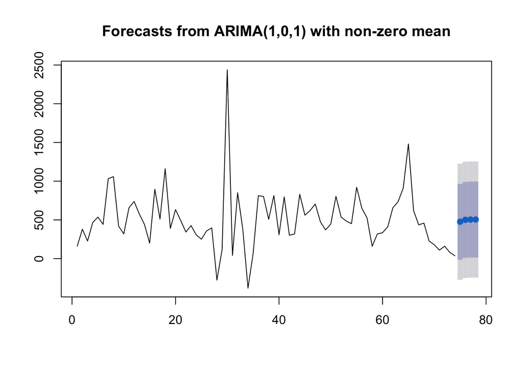

```r
plot(fc)
```

```r
fc_log <- forecast(ARMA_fdilog, h = 4)

# Visualiza el pronóstico con una gráfica
print(fc_log)
```

```
##    Point Forecast    Lo 80    Hi 80    Lo 95    Hi 95
## 75       5.469758 2.885057 8.054459 1.516799 9.422717
## 76       5.817148 3.190767 8.443529 1.800445 9.833852
## 77       5.672562 3.039027 8.306096 1.644918 9.700205
## 78       5.732740 3.097968 8.367511 1.703204 9.762275
```

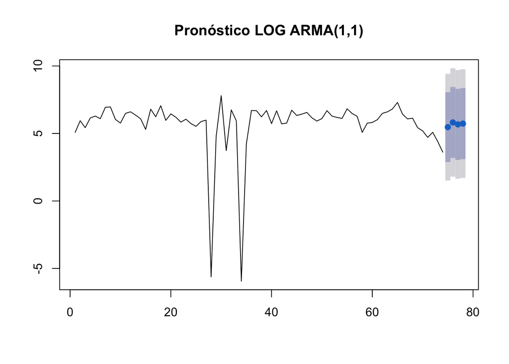

```r
plot(fc_log, main = "Pronóstico LOG ARMA(1,1)")
```

### Modelo Seleccionado y Predicción

```r
# Ratio Method
fc_log <- forecast(ARMA_fdilog, h = 4)
fc_real <- fc_log

# Revertimos la transformación de la media
fc_real$mean  <- exp(fc_log$mean) - 1

# Aplicamos la transformación del ratio usando la proporción del valor real
fc_real$lower <- (fc_real$mean * (fc_log$lower / fc_log$mean))
fc_real$upper <- (fc_real$mean * (fc_log$upper / fc_log$mean))

# Revertimos la transformación en la serie original
fc_real$x <- exp(fc_log$x) - 1

# Mostrar resultados
print(fc_real)
```

```
##    Point Forecast    Lo 80    Hi 80     Lo 95    Hi 95
## 75       236.4027 124.6921 348.1134  65.55599 407.2495
## 76       335.0124 183.7578 486.2670 103.68849 566.3364
## 77       289.7784 155.2464 424.3105  84.02938 495.5275
## 78       307.8142 166.3425 449.2858  91.45197 524.1764
```

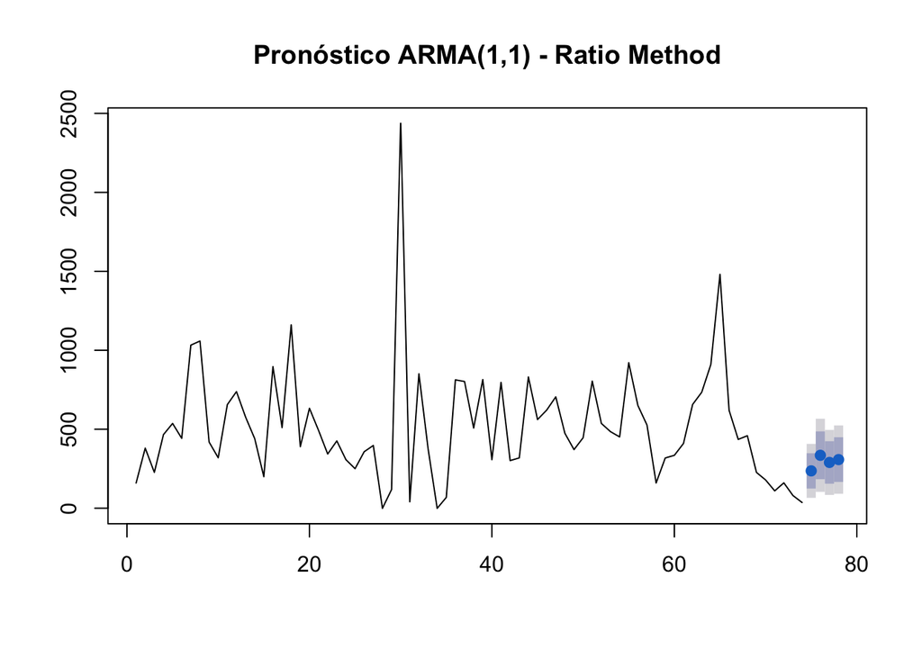

```r
plot(fc_real, main = "Pronóstico ARMA(1,1) - Ratio Method")
```

#### Describir cómo es la tendencia del pronóstico de la(s) serie(s) de tiempo de la(s) variable(s) seleccionadas para los siguientes 4 períodos.

La tendencia de la serie de tiempo **muestra fluctuaciones moderadas en los siguientes cuatro períodos**, con un **leve crecimiento en el segundo período seguido de una ligera reducción** en los valores pronosticados:

- **Primer período (t=75)**: Se espera un valor de **236.40**, con un intervalo del **80% entre 124.69 y 348.11**, y del **95% entre 65.55 y 407.24**.
- **Segundo período (t=76)**: Aumento a **335.01**, con intervalos más amplios (**80%: 183.75 - 486.26**, **95%: 103.68 - 566.33**).
- **Tercer período (t=77)**: Descenso a **289.77**, con menor dispersión en los intervalos.
- **Cuarto período (t=78)**: Recuperación a **307.81**, aunque dentro de un rango incierto.

En general, el modelo predice valores **sin una tendencia definida**, pero con **una variabilidad controlada** dentro de los intervalos de confianza.

#### De acuerdo al pronóstico anterior, ¿cómo es el escenario optimista vs. escenario pesimista del posible “Nearshoring” para el caso de México?

- **Escenario optimista** 📈
  - Si el nearshoring sigue impulsando la IED, **los valores podrían acercarse o superar los límites superiores de los intervalos de confianza**.
  - Un **escenario con estabilidad macroeconómica y políticas favorables** podría situar la IED cerca de los **486.26 - 566.33 millones** en el segundo período, favoreciendo el crecimiento del sector manufacturero.
  - La recuperación en el cuarto período sugiere que, **bajo condiciones óptimas**, el nearshoring podría sostener niveles de inversión estables a mediano plazo.
- **Escenario pesimista** 📉
  - En caso de **incertidumbre económica, cambios en regulaciones o pérdida de confianza**, la IED podría acercarse a los **límites inferiores**, con valores cercanos a **65.55 - 183.75 millones**.
  - Un patrón de **volatilidad en las exportaciones o depreciación del peso** podría reducir el atractivo del nearshoring en México.
  - La posible caída en el tercer período sugiere **riesgo de reversión del crecimiento** si no hay estabilidad en la demanda global.

El **escenario optimista implica estabilidad y crecimiento** en la IED, mientras que el **escenario pesimista refleja riesgos de desaceleración y baja inversión** aunque ambos mostrandose dentro de un escenario conservador.

#### El desempeño del flujo de nuevos flujos de IED exhiben la presencia de un cambio estructural durante el período de análisis?

No, el desempeño de los flujos de IED en general **no sugiere la presencia de un cambio estructural claro y consistente** a lo largo de la serie, aunque ciertos períodos muestran fluctuaciones abruptas que podrían estar asociadas con factores externos o ajustes en la estrategia de inversión:

- **Eventos exógenos y ajustes empresariales:** Se observan **picos y caídas abruptas** en años como 2013 y 2021, lo que podría indicar **shocks externos** o **reconfiguraciones en los patrones de inversión** en respuesta a cambios en la economía global.
- **Resultados de la prueba ADF:** La estacionariedad de la serie implica que **no hay una tendencia de largo plazo claramente definida**, aunque la inversión podría responder a **perturbaciones externas no incluidas en el modelo**.
- **Análisis de autocorrelación (ACF):** No se identifican patrones fuertes más allá del primer rezago, lo que sugiere que la IED **no sigue un comportamiento cíclico definido** y que las variaciones pueden ser más esporádicas que estructurales.
- **Resultados del modelo VAR:** No se encontró **evidencia significativa de causalidad** entre el tipo de cambio y la IED, lo que indica que cualquier relación entre ambas variables podría ser **indirecta o depender de otros factores macroeconómicos**.

Aunque **no hay evidencia contundente de un cambio estructural en toda la serie**, algunas fluctuaciones justifican un análisis más detallado. **Aplicar una prueba de Chow** podría ayudar a evaluar directamente la existencia de posibles cambios estructurales en períodos clave.

## Conclusiones

- **IED y nearshoring:** No se identificó un cambio estructural claro en la IED, aunque ciertos períodos exhibieron fluctuaciones abruptas, posiblemente relacionadas con eventos exógenos. La proyección a corto plazo indica **variabilidad moderada sin una tendencia definida**, lo que refleja la incertidumbre inherente al nearshoring.
- **Tipo de cambio y exportaciones:** Se observó una **tendencia creciente en el tipo de cambio**, con períodos de relativa estabilidad seguidos de aumentos significativos. Las exportaciones, en cambio, **mostraron un crecimiento sostenido**, lo que respalda la idea de que México ha fortalecido su papel en la cadena global de suministro.
- **Estacionariedad y pronósticos:** La prueba ADF confirmó la **estacionariedad en la serie de IED**, lo que permitió el uso de modelos ARMA sin diferenciación. La proyección con **ARMA(1,1)** ofrece **un panorama razonablemente estable**, aunque con márgenes de incertidumbre en los escenarios optimistas y pesimistas.

Los pronósticos obtenidos **presentan una estructura inusual**, en gran parte debido a la transformación de variables necesaria para el análisis. Sin estas transformaciones, **las variables mostraban alta incertidumbre y errores significativos en los modelos**, lo que dificultaba obtener predicciones confiables. Sin embargo, dentro de estas limitaciones, el modelo ARMA(1,1) permite **realizar pronósticos confiables a corto plazo**, proporcionando herramientas útiles para la toma de decisiones en materia de inversión extranjera.

En el futuro, complementar este estudio con un análisis Panel-VAR permitiría una interpretación más robusta, integrando **tanto la dimensión temporal como la heterogeneidad entre observaciones**, logrando un balance entre **patrones generales y detalles específicos** de los flujos de inversión en México.

## Referencias

Comisión Económica para América Latina y el Caribe (CEPAL). (2022). México en la fábrica de América del Norte y el nearshoring. Recuperado de https://repositorio.cepal.org/bitstream/handle/11362/48056/1/S2200726_es.pdf

Lütkepohl, H. (2005). New Introduction to Multiple Time Series Analysis. Springer.

Morales, V. (s.f.). Modelización de Series Multivariantes: VAR & VEC. Recuperado de https://bookdown.org/victor_morales/SeriesdeTiempo/modelizaci%C3%B3n-de-series-multivariantes-var-vec.html